# EDA_text_EY

```r
library(readr)
sale_listings <- read_csv("capstone_data/sale_listings.csv")
amenities <- read_csv("capstone_data/amenities.csv")
```

## Data Cleaning

```r
#make state names consistent
sale_listings_clean <- sale_listings %>%
  mutate(addr_state = ifelse(addr_state == "New Jersey", "NJ", ifelse(addr_state == "New York", "NY", addr_state)))

#create log price var
sale_listings_clean <- sale_listings_clean %>%
  mutate(log_price = log(price))
```

```r
#make the spelling of cities consistent
sale_listings_clean <- sale_listings_clean %>%
  mutate(addr_city = tolower(addr_city)) %>%
  mutate(addr_city = recode(addr_city,
                            "apt.7" = "west new york",
                            "1214 - north brunswick" = "north bergen",
                            "77 hudson - jersey city" = "jersey city",
                            "arvene" = "arverne",
                            "bayonne city" = "bayonne",
                            "brook;yn" = "brooklyn",
                            "brookyn" = "brooklyn",
                            "e. elmhurst" = "east elmhurst",
                            "jersey city bergen/ lafayette" = "jersey city bergen-lafayett",
                            "jc, bergen-lafayett" = "jersey city bergen-lafayett",
                            "jc, downtown" = "jersey city downtown",
                            "jc, greenville" = "jersey city greenville",
                            "jc, journal square" = "jersey city jsq",
                            "journal square" = "jersey city jsq",
                            "kearney" = "kearny",
                            "neponsit ny" = "neponsit",
                            "queen" = "queens",
                            "queens village n" = "queens village",
                            "richmond hill s." = "richmond hill",
                            "west ny" = "west new york",
                            "springfield gdns" = "springfield gardens",
                            "s. ozone park" = "south ozone park"))

sale_listings_clean %>%
  group_by(addr_city) %>%
  summarize(mean = mean(price), n=n())
```

```
## # A tibble: 112 x 3
##    addr_city              mean     n
##    <chr>                 <dbl> <int>
##  1 arverne             573835.    34
##  2 astoria            1161481.   612
##  3 bath beach          731286.     7
##  4 bayonne             434538.   708
##  5 bayside             808332.   365
##  6 bedford-stuyvesant 2599000      1
##  7 beechhurst          522933      5
##  8 belle harbor       1225000      1
##  9 bellerose           662790.    61
## 10 breezy point        385000      1
## # … with 102 more rows
```

```r
amenities %>%
  group_by(name) %>%
  summarize(n=n())
```

```
## # A tibble: 120 x 2
##    name                        n
##    <chr>                   <int>
##  1 assigned_parking           64
##  2 balcony                   981
##  3 basement_finished          24
##  4 basement_full              17
##  5 basement_partial            2
##  6 basement_unfinished         3
##  7 bayfront                   14
##  8 beachfront                  6
##  9 bike_room                3632
## 10 board_approval_required     2
## # … with 110 more rows
```

## Exploratory Data Analysis

```r
#the unique property id of amenities and sale_listings do not match
length(unique(amenities$property_id))
```

```
## [1] 9323
```

```r
length(unique(sale_listings$property_id))
```

```
## [1] 51355
```

```r
summary(sale_listings_clean)
```

```
##        id         property_id         unittype           subject
##  Min.   :    1   Min.   :   70835   Length:59661       Length:59661
##  1st Qu.:14916   1st Qu.: 1282020   Class :character   Class :character
##  Median :29831   Median : 8814131   Mode  :character   Mode  :character
##  Mean   :29831   Mean   : 6316133
##  3rd Qu.:44746   3rd Qu.: 9288704
##  Max.   :59661   Max.   :10158507
##                  NA's   :1284
##  listing_description    bedrooms        bathrooms        anyrooms
##  Length:59661        Min.   : 0.000   Min.   : 0.00   Min.   :   0.000
##  Class :character    1st Qu.: 1.000   1st Qu.: 1.00   1st Qu.:   2.000
##  Mode  :character    Median : 2.000   Median : 2.00   Median :   4.000
##                      Mean   : 2.623   Mean   : 1.94   Mean   :   5.341
##                      3rd Qu.: 3.000   3rd Qu.: 2.00   3rd Qu.:   6.000
##                      Max.   :99.000   Max.   :66.00   Max.   :3200.000
##
##    size_sqft          price           addr_street         addr_unit
##  Min.   :     0   Min.   :        1   Length:59661       Length:59661
##  1st Qu.:   545   1st Qu.:   539500   Class :character   Class :character
##  Median :  1000   Median :   845000   Mode  :character   Mode  :character
##  Mean   :  1333   Mean   :  1527538
##  3rd Qu.:  1706   3rd Qu.:  1500000
##  Max.   :588527   Max.   :108000000
##  NA's   :11244
##   addr_cross         addr_hood          addr_city          addr_state
##  Length:59661       Length:59661       Length:59661       Length:59661
##  Class :character   Class :character   Class :character   Class :character
##  Mode  :character   Mode  :character   Mode  :character   Mode  :character
##
##
##
##
##     addr_zip        addr_lon          addr_lat     time_to_subway
##  Min.   : 7002   Min.   :-102.39   Min.   : 0.00   Min.   :      1
##  1st Qu.:10014   1st Qu.: -74.00   1st Qu.:40.68   1st Qu.:    108
##  Median :10303   Median : -73.97   Median :40.73   Median :    199
##  Mean   :10171   Mean   : -71.26   Mean   :39.25   Mean   :   3206
##  3rd Qu.:11224   3rd Qu.: -73.92   3rd Qu.:40.76   3rd Qu.:    374
##  Max.   :11697   Max.   :  73.78   Max.   :51.59   Max.   :6200617
##  NA's   :5       NA's   :69        NA's   :69      NA's   :10274
```

[output cut: 9 more lines]

```
##  Min.   :  0.00   Min.   :   0.0         Min.   :   0.00   Min.   :   0
##  1st Qu.:  2.00   1st Qu.:   2.0         1st Qu.:   2.00   1st Qu.:1924
##  Median :  5.00   Median :  38.0         Median :  27.00   Median :1951
##  Mean   : 10.09   Mean   : 100.9         Mean   :  90.37   Mean   :1944
##  3rd Qu.: 13.00   3rd Qu.: 133.0         3rd Qu.: 120.00   3rd Qu.:1999
##  Max.   :131.00   Max.   :3857.0         Max.   :3857.00   Max.   :2021
##                   NA's   :10635          NA's   :11878     NA's   :7839
##   is_historic     landmark_name       area_name           log_price
##  Min.   :0.0000   Length:59661       Length:59661       Min.   : 0.00
##  1st Qu.:0.0000   Class :character   Class :character   1st Qu.:13.20
##  Median :0.0000   Mode  :character   Mode  :character   Median :13.65
##  Mean   :0.0786                                         Mean   :13.75
##  3rd Qu.:0.0000                                         3rd Qu.:14.22
##  Max.   :1.0000                                         Max.   :18.50
##  NA's   :2
```

```r
#examine listings with odd numbers

#sale_listings_clean %>%
#  filter(bedrooms == 99)

#sale_listings_clean %>%
#  arrange(desc(bedrooms))

#sale_listings_clean %>%
#  arrange(desc(bathrooms))

#sale_listings_clean %>%
#  filter(price == 1)

#sale_listings_clean %>%
#  filter(size_sqft == 588527)

#sale_listings_clean %>%
#  filter(year_built == 0)
```

### Questions:

- 1. the maximum number is 99 for bedrooms, 66 for bathrooms, 3200 for anyrooms, 247 for building_count (n. of buildings). I tend to think the listing with 99 bedrooms is a data entry mistake since it only has 9 rooms in total? The two listings with 66 bathrooms also seem impossible since it does not have data on size_sqft. Also the maximum for size_sqft is 588527, which seems odd.

A methodological question: how could we systematically identify data that seems odd and how do we know if that’s a mistake in data entry or not

- 2. variables missing over 6000 obs: time_to_subway (10274 NA), census_block (12011 NA), building_count (11242 NA), residential_unit_count (10635 NA), total_unit_count (11878 NA), year_built (7839 NA)
- 3. the minimum price is 1, which doesn’t make sense; it corresponds to two listings with the same addr_stree, longitude & latitude, but different size_sqft. There are 315 entries with year built = 0.
- 4. although anyrooms mean the total number of rooms, it is strange that sometimes anyrooms is smaller than/ equal to bedrooms
- 5. In data dictionary, it says “One property can correspond to more than listing, if it has been listed more than once.” Should we remove duplicates based on some criteria (if there is any)?

## Data visualization

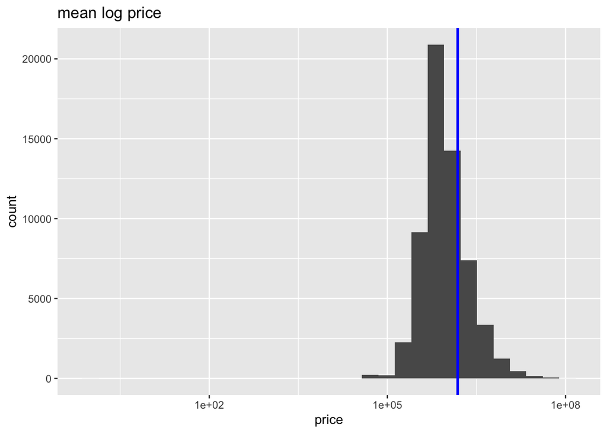

```r
#histogram of price: extremely skewed
mean_price <- mean(sale_listings_clean$price)
mean_price_p <- sale_listings_clean %>%
  ggplot(aes(x=price)) +
  geom_histogram() +
  geom_vline(xintercept = mean_price, size = 1, color = "blue")

#log price - looks better
sale_listings_clean %>%
  ggplot(aes(x=price)) +
  geom_histogram() +
  scale_x_log10() +
  geom_vline(xintercept = mean_price, size = 1, color = "blue") +
  ggtitle("mean log price")
```

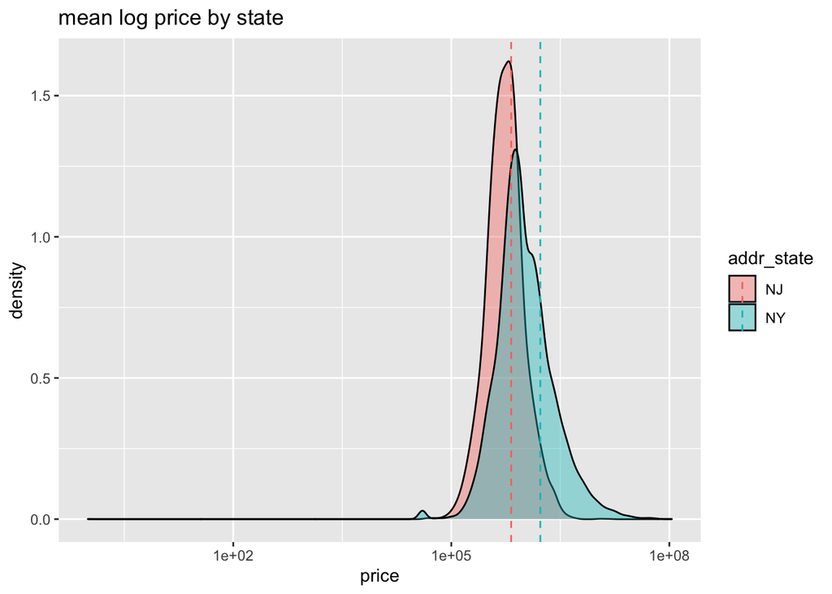

```r
mean_st <- sale_listings_clean %>%
  group_by(addr_state) %>%
  summarize(n = n(), mean = mean(price))

#compare log distribution and mean price between NJ and NY
ggplot(data=sale_listings_clean, aes(x=price, fill=addr_state)) +
  geom_density(adjust=1.5, alpha=.4) +
  geom_vline(data = mean_st, aes(xintercept = mean, color = addr_state), linetype="dashed") +
  scale_x_log10() +
  ggtitle("mean log price by state")
```

Mean price = 1527538. NJ has 8877 listings, raw mean price is 666404.3; NY has 50784 listings, mean price is 1678063.1.

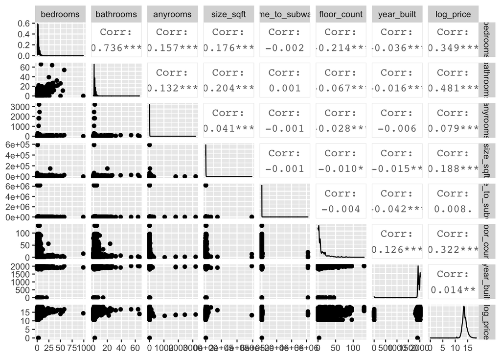

```r
#correlation plot
sale_cor <- sale_listings_clean %>%
  dplyr::select(bedrooms, bathrooms, anyrooms, size_sqft, time_to_subway, floor_count, year_built, log_price)

sale_cor %>%
  GGally::ggpairs()
```

- many variables are extremely skewed: how do we deal with that

## tokenization, bigrams, and word counts

```r
#only select property_id and descriptions
sale_text <- sale_listings %>%
  select(property_id, listing_description)

text <- tibble(txt = sale_text$listing_description)

#split text into single words and remove stop words
sale_text_tk <- text %>%
  unnest_tokens(word, txt) %>%
  anti_join(stop_words)
```

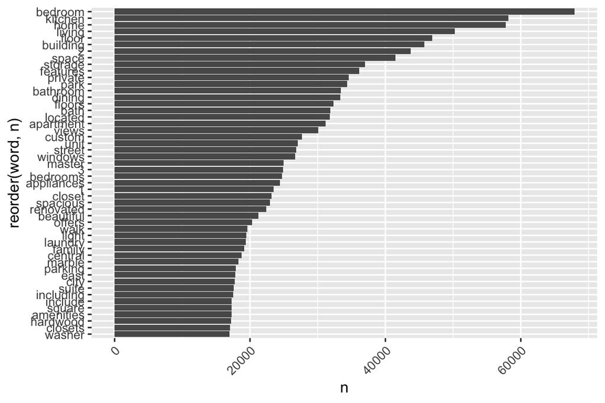

```r
sale_tk_count <- sale_text_tk %>%
   count(word, sort = TRUE) %>%
  arrange(desc(n))

uni_freq <- sale_tk_count %>%
  head(50) %>%
  ggplot(aes(y=reorder(word,n), x = n)) +
  geom_bar(stat = "identity")

uni_freq + theme(axis.text.x=element_text(angle=45, hjust=1))
```

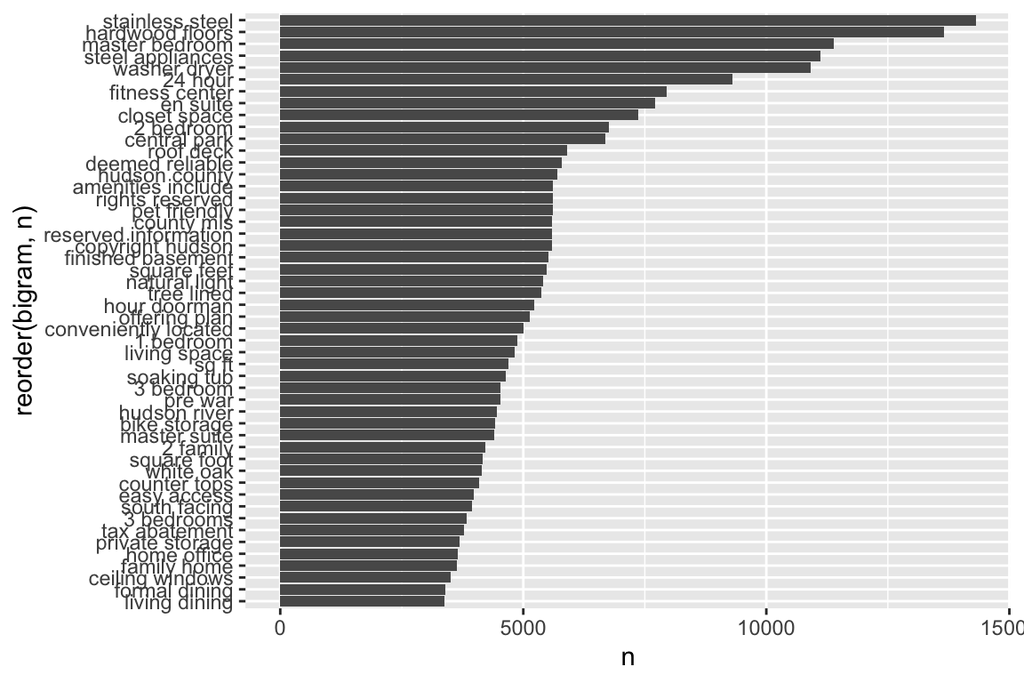

```r
#split text into bigrams and remove stop words
#2 grams take forever to run
sale_bigram <- text %>%
  unnest_tokens(bigram, txt, token = 'ngrams', n=2) %>%
  separate(bigram, c('word1', 'word2'), sep = " ") %>%
  filter(!word1 %in% stop_words$word) %>%
  filter(!word2 %in% stop_words$word) %>%
  unite(bigram, word1, word2, sep = " ")

sale_bi_count <- sale_bigram %>%
  count(bigram, sort = TRUE) %>%
  arrange(desc(n))


bi_freq <- sale_bi_count %>%
  head(50) %>%
  ggplot(aes(y=reorder(bigram,n), x = n)) +
  geom_bar(stat = "identity")
bi_freq
```